# Question

Juan, Valentina y Patricia son los únicos dueños de una empresa. Juan tiene 1 acciones; Valentina, 5; y Patricia, 30. El año pasado, las ganancias fueron de $525.000.000 y ellos quieren repartirlas proporcionalmente, de modo que, a quien más tenga acciones, le correspondan más ganancias. Para saber qué parte del dinero le correspondió a Juan, este plantea dos procedimientos:

**Procedimiento 1.** Dividir las ganancias en 36 partes y, luego, multiplicar ese valor por 1.

**Procedimiento 2.** Dividir 1 por 36 y multiplicar por 100.

¿Cuál o cuáles de los procedimientos es o son correctos?

## Answerlist

- Solo el procedimiento 2 es correcto
- Ninguno de los procedimientos es correcto
- Ambos procedimientos son correctos
- Solo el procedimiento 1 es correcto

# Solution

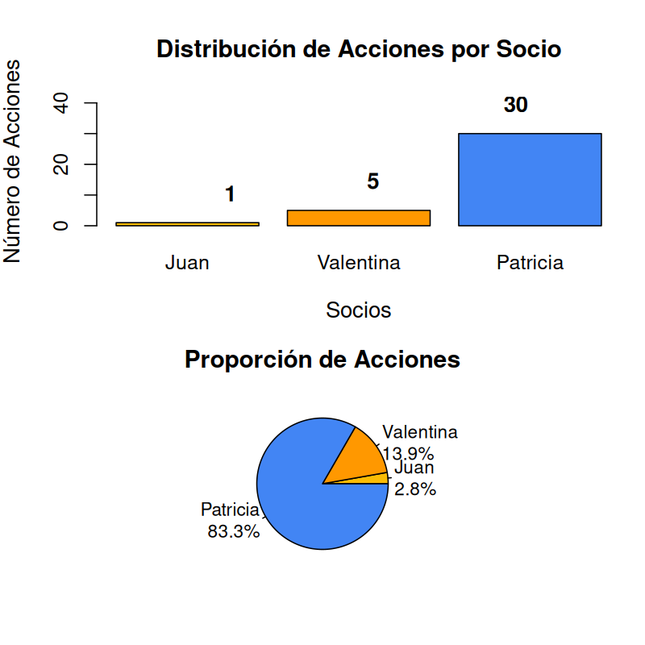

Para resolver este problema de reparto proporcional, debemos analizar cada procedimiento y verificar si calcula correctamente la parte que le corresponde a Juan.

### Datos del problema:

- Juan: 1 acciones
- Valentina: 5 acciones
- Patricia: 30 acciones
- **Total de acciones**: 36 acciones
- **Ganancias totales**: $525.000.000

### Método correcto para el reparto proporcional:

El reparto debe ser proporcional al número de acciones que posee cada socio. La fórmula correcta es:

**Ganancia de cada socio = (Número de acciones del socio ÷ Total de acciones) × Ganancias totales**

Para Juan:

Ganancia = (1 ÷ 36) × $525.000.000

Esto es equivalente a:

1. Dividir las ganancias totales entre el número total de acciones para obtener el valor por acción
2. Multiplicar ese valor por el número de acciones de Juan

**Valor por acción** = $525.000.000 ÷ 36 = $14.583.333

**Ganancia de Juan** = $14.583.333 × 1 = $14.583.333

### Análisis de los procedimientos:

**Procedimiento 1:**

Dividir las ganancias en 36 partes y, luego, multiplicar ese valor por 1

- Resultado: $14.583.333
- CORRECTO

**Procedimiento 2:**

### Verificación:

Comprobemos que el reparto es proporcional:

- Juan (1 acciones): $14.583.333 = 2.8% del total
- Valentina (5 acciones): $72.916.667 = 13.9% del total
- Patricia (30 acciones): $437.500.000 = 83.3% del total

**Total verificado**: $525.000.000

Por lo tanto, **Solo el procedimiento 1 es correcto**.

## Answerlist

- Falso
- Falso
- Falso
- Verdadero

# Meta-information

exname: proporcionalidad_empresarial_formulacion_ejecucion extype: schoice exsolution: 0001 exshuffle: TRUE exsection: Álgebra y Cálculo|Proporcionalidad|Reparto proporcional